**PREDICTING QUALITY OF DUMBBELL BICEPS CURL**  
by Lorelie Calima-Prall  
March 4, 2016

**Executive Summary**  
Based on weight lifting exercises data from http://groupware.les.inf.puc-rio.br/har, the goal of this project is to predict the manner in which the dumbbell bicep curl was performed. This is the “classe” variable in the training set. This report describes how the model was built, how cross validation was implemented, what the expected out of sample error is and why certain choices were made. The resulting model is also used to predict 20 different test cases.

The training data for this project is downloaded from:  
https://d396qusza40orc.cloudfront.net/predmachlearn/pml-training.csv

The test data is available from:  
https://d396qusza40orc.cloudfront.net/predmachlearn/pml-testing.csv

```r
trainurl<-"https://d396qusza40orc.cloudfront.net/predmachlearn/pml-training.csv"
traindest<-"C:/Users/Lorelie/Documents/Classes/Coursera/Data Science/08_Practical_Machine_Learning/04_Week/Project/traindata.csv"
download.file(trainurl,traindest)

testurl<-"https://d396qusza40orc.cloudfront.net/predmachlearn/pml-testing.csv"
testdest<-"C:/Users/Lorelie/Documents/Classes/Coursera/Data Science/08_Practical_Machine_Learning/04_Week/Project/testdata.csv"
download.file(testurl,testdest)

train <- read.csv(traindest,na.strings=c("#DIV/0!"))
test <- read.csv(testdest,na.strings=c("#DIV/0!"))

require(dplyr)
glimpse(train)
```

```
Observations: 19,622
Variables: 160
$ X                        (int) 1, 2, 3, 4, 5, 6, 7, 8, 9, 10, 11, 12...
$ user_name                (fctr) carlitos, carlitos, carlitos, carlit...
$ raw_timestamp_part_1     (int) 1323084231, 1323084231, 1323084231, 1...
$ raw_timestamp_part_2     (int) 788290, 808298, 820366, 120339, 19632...
$ cvtd_timestamp           (fctr) 05/12/2011 11:23, 05/12/2011 11:23, ...
$ new_window               (fctr) no, no, no, no, no, no, no, no, no, ...
$ num_window               (int) 11, 11, 11, 12, 12, 12, 12, 12, 12, 1...
$ roll_belt                (dbl) 1.41, 1.41, 1.42, 1.48, 1.48, 1.45, 1...
$ pitch_belt               (dbl) 8.07, 8.07, 8.07, 8.05, 8.07, 8.06, 8...
$ yaw_belt                 (dbl) -94.4, -94.4, -94.4, -94.4, -94.4, -9...
$ total_accel_belt         (int) 3, 3, 3, 3, 3, 3, 3, 3, 3, 3, 3, 3, 3...
$ kurtosis_roll_belt       (dbl) NA, NA, NA, NA, NA, NA, NA, NA, NA, N...
$ kurtosis_picth_belt      (dbl) NA, NA, NA, NA, NA, NA, NA, NA, NA, N...
```

[output cut: 147 more lines]

**Clean Data**  
Remove columns with NA values, those that are insignificant and have zero variance.

```r
library(caret)
train<-train[,colSums(is.na(train)) ==0]
colnames(train)[colSums(is.na(train)) > 0]
```

```
character(0)
```

```r
dropcols<-names(train) %in% c('X', 'user_name', 'raw_timestamp_part_1', 'raw_timestamp_part_2', 'cvtd_timestamp', 'new_window', 'num_window')
train <- train[!dropcols]

nzv <- nearZeroVar(train)
train <- train[, -nzv]
```

**Split Data for Cross-Validation**

```r
library(caret)
trainIndex <- createDataPartition(train$classe, p =0.8,list = FALSE,times=1)
train <-train[trainIndex,]
valid <-train[-trainIndex,]
```

**Random Forests Model**

```r
library(randomForest)
trainrf<-randomForest(classe~.,data=train,importance=TRUE)
trainrf
```

```
Call:
 randomForest(formula = classe ~ ., data = train, importance = TRUE)
               Type of random forest: classification
                     Number of trees: 500
No. of variables tried at each split: 7

        OOB estimate of  error rate: 0.34%
Confusion matrix:
     A    B    C    D    E  class.error
A 4461    2    0    0    1 0.0006720430
B   10 3024    4    0    0 0.0046082949
C    0   16 2719    3    0 0.0069393718
D    0    0   16 2557    0 0.0062184221
E    0    0    0    2 2884 0.0006930007
```

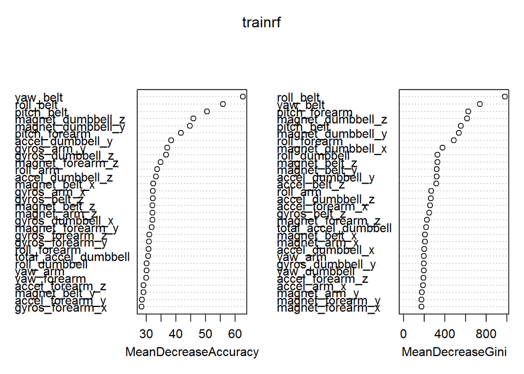

```r
varImpPlot(trainrf)
```

```r
predvalid<-predict(trainrf,valid)
confusionMatrix(valid$classe, predvalid)
```

```
Confusion Matrix and Statistics

          Reference
Prediction   A   B   C   D   E
         A 874   0   0   0   0
         B   0 608   0   0   0
         C   0   0 578   0   0
         D   0   0   0 501   0
         E   0   0   0   0 574

Overall Statistics

               Accuracy : 1
                 95% CI : (0.9988, 1)
    No Information Rate : 0.2788
    P-Value [Acc > NIR] : < 2.2e-16

                  Kappa : 1
 Mcnemar's Test P-Value : NA

Statistics by Class:

                     Class: A Class: B Class: C Class: D Class: E
Sensitivity            1.0000   1.0000   1.0000   1.0000   1.0000
Specificity            1.0000   1.0000   1.0000   1.0000   1.0000
Pos Pred Value         1.0000   1.0000   1.0000   1.0000   1.0000
Neg Pred Value         1.0000   1.0000   1.0000   1.0000   1.0000
Prevalence             0.2788   0.1939   0.1844   0.1598   0.1831
Detection Rate         0.2788   0.1939   0.1844   0.1598   0.1831
Detection Prevalence   0.2788   0.1939   0.1844   0.1598   0.1831
Balanced Accuracy      1.0000   1.0000   1.0000   1.0000   1.0000
```

```r
accuracy <- postResample(valid$classe, predvalid)
accuracy <-accuracy[[1]]
accuracy
```

```
[1] 1
```

```r
oose<-1-accuracy
oose
```

```
[1] 0
```

**Predicting with Random Forests**

```r
pred<-predict(trainrf,test)
pred
```

```
 1  2  3  4  5  6  7  8  9 10 11 12 13 14 15 16 17 18 19 20
 B  A  B  A  A  E  D  B  A  A  B  C  B  A  E  E  A  B  B  B
Levels: A B C D E
```